# Regex in quanteda

Teodor Petrič

2021-6-4

# 0. Programi

Najprej moramo zagnati programe, ki jih potrebujemo za načrtovano delo.

```r
library(readtext)
library(quanteda)
library(quanteda.textstats)
```

```r
library(quanteda.textplots)
library(tidyverse)
```

# 1. Preberemo besedila

```r
txt = readtext("data/books/*.txt", encoding = "UTF-8")
txt
```

```
## readtext object consisting of 2 documents and 0 docvars.
## # Description: df[,2] [2 x 2]
##   doc_id      text
##   <chr>       <chr>
## 1 prozess.txt "\"Der Prozes\"..."
## 2 tom.txt     "\"Tom Sawyer\"..."
```

# 2. Ustvarimo korpus

Ustvarimo korpus ali jezikovno gradivo. Ukaz v programu “quanteda” je corpus().

```r
romane = corpus(txt)
```

# 3. Tokenizacija

```r
woerter = tokens(romane)
```

# 4. Kwic

Za sestavo konkordanc ima program quanteda funkcijo *kwic()* (keyword in context).

Možno je iskati posamezne besede, besedne zveze, uporabljamo pa lahko tudi nadomestne znake (npr. *).

```r
kwic(woerter, pattern = c("Frau", "Herr"))
```

```
## Keyword-in-context with 226 matches.
##     [prozess.txt, 23]              1 Verhaftung, Gespräch mit | Frau |
##     [prozess.txt, 55]               verhaftet. Die Köchin der | Frau |
##     [prozess.txt, 97]          seinem Kopfkissen aus die alte | Frau |
##    [prozess.txt, 417]             im Nebenzimmer sind und wie | Frau |
##    [prozess.txt, 552]               Es war das Wohnzimmer der | Frau |
##    [prozess.txt, 675]           erblickte man wieder die alte | Frau |
##    [prozess.txt, 701]                       . » Ich will doch | Frau |
##   [prozess.txt, 1648]    gerade die gegenüberliegende Tür und | Frau |
##   [prozess.txt, 2423]                  drüben sah er die alte | Frau |
##   [prozess.txt, 2869]                       war, so konnte er | Frau |
##   [prozess.txt, 5961]             . Im Vorzimmer öffnete dann | Frau |
##   [prozess.txt, 6558]               in der ganzen Wohnung der | Frau |
##   [prozess.txt, 6732]         Sohn des Hausmeisters, gnädiger | Herr |
##   [prozess.txt, 6773]                 . » Wünscht der gnädige | Herr |
##   [prozess.txt, 6853]                        , aber da er mit | Frau |
##   [prozess.txt, 6896]                     so spät komme, aber | Frau |
##   [prozess.txt, 6995]             hinaustragen können. Er sah | Frau |
##   [prozess.txt, 7196]                   . Nur mit einer alten | Frau |
##   [prozess.txt, 7292]              vertraulich mit mir reden, | Herr |
##   [prozess.txt, 7458]                   was Sie gesagt haben, | Frau |
##   [prozess.txt, 7696]         , das Urteil einer vernünftigen | Frau |
##   [prozess.txt, 7751]                   dachte er und sah die | Frau |
##   [prozess.txt, 7821]                   doch nicht so schwer, | Herr |
##   [prozess.txt, 7865]  das Wertlose aller Zustimmungen dieser | Frau |
##   [prozess.txt, 7888]                         » Nein «, sagte | Frau |
##   [prozess.txt, 8007]                    Das ist nicht nötig, | Herr |
##   [prozess.txt, 8141]                        sagte K. und sah | Frau |
##   [prozess.txt, 8161]                     Leute sind! « sagte | Frau |
##   [prozess.txt, 8191]                        kann es «, sagte | Frau |
##   [prozess.txt, 8201]                   sehr haben Sie recht, | Herr |
##   [prozess.txt, 8288]                        Gott, nur Ihnen, | Herr |
##   [prozess.txt, 8427]                         Gute Nacht. « » | Herr |
##   [prozess.txt, 8433]                             K. «, sagte | Frau |
##   [prozess.txt, 8625]           einen Augenblick sogar daran, | Frau |
##   [prozess.txt, 9087]                             vor. » Ach, | Herr |
##  [prozess.txt, 11021]              schläft hier ein Neffe von | Frau |
##  [prozess.txt, 11199]                    Sie wissen, wie mich | Frau |
##  [prozess.txt, 11273]                    , und verbürge mich, | Frau |
##  [prozess.txt, 11316]                überfallen habe, so wird | Frau |
```

[output cut: 399 more lines]

```
##  Gott, ich wag's nicht
##  des Richters Thatcher auf Frau
##  Harper zu, die mit
##  Thatcher schüttelte schwach den Kopf
##  Harper. In Tante Pollys
##  Thatcher fiel in Ohnmacht,
##  Thatcher, und versuchten,
##  Thatcher war völlig verzweifelt,
##  Thatcher erkannte das Band und
##  da weinte. Solche trüben
##  Thatcher erfuhr, daß Becky
##  Thatcher war sehr krank und
##  Thatchers Hand, suchte vergebens
##  Thatchers beinahe. Vollkommen konnte
##  Richter - in der Höhle
```

Konkordanco bomo pretvorili v podatkovno zbirko, tj. *data.frame* ali *tibble()*. Prednost je npr., da tako pridobimo imena stolpcev (tj. spremenljivk).

*kwic()* ima več možnosti, npr. “case_insensitive = FALSE” razlikuje med velikimi in malimi črkami. Privzeta vrednost je “TRUE”, tj. da tega ne razlikuje (tako kot Excel).

```r
(konkordanca = kwic(woerter, pattern = c("Frau", "Herr"), case_insensitive = FALSE) %>%
  as_tibble()
)
```

```
## # A tibble: 226 x 7
##    docname    from    to pre                 keyword post                pattern
##    <chr>     <int> <int> <chr>               <chr>   <chr>               <fct>
##  1 prozess.~    23    23 1 Verhaftung , Ges~ Frau    Grubach , dann Frä~ Frau
##  2 prozess.~    55    55 verhaftet . Die Kö~ Frau    Grubach , seiner Z~ Frau
##  3 prozess.~    97    97 seinem Kopfkissen ~ Frau    , die ihm gegenübe~ Frau
##  4 prozess.~   417   417 im Nebenzimmer sin~ Frau    Grubach diese Stör~ Frau
##  5 prozess.~   552   552 Es war das Wohnzim~ Frau    Grubach , vielleic~ Frau
##  6 prozess.~   675   675 erblickte man wied~ Frau    , die mit wahrhaft~ Frau
##  7 prozess.~   701   701 . » Ich will doch   Frau    Grubach - « , sagte Frau
##  8 prozess.~  1648  1648 gerade die gegenüb~ Frau    Grubach wollte dor~ Frau
##  9 prozess.~  2423  2423 drüben sah er die ~ Frau    , die einen noch v~ Frau
## 10 prozess.~  2869  2869 war , so konnte er  Frau    Grubach als Zeugin~ Frau
## # ... with 216 more rows
```

Z ukazom *count()* lahko preštejemo, koliko pojavnic je *kwic()* našel v jezikovnem gradivu.

```r
konkordanca %>%
  count(keyword)
```

```
## # A tibble: 2 x 2
##   keyword     n
##   <chr>   <int>
## 1 Frau      132
## 2 Herr       94
```

## Pripona -in

Poiskati želimo besede s pripono “-in” za samostalnike, ki označujejo ženska osebna imena (npr. Ärztin, Köchin, …).

```r
(konkordanca2 <- kwic(woerter, pattern = c("*in"), case_insensitive = FALSE) %>%
  as_tibble()
)
```

```
## # A tibble: 4,100 x 7
##    docname    from    to pre             keyword     post                pattern
##    <chr>     <int> <int> <chr>           <chr>       <chr>               <fct>
##  1 prozess.~    27    27 mit Frau Gruba~ Fräulein    Brüstner Jemand mu~ *in
##  2 prozess.~    53    53 eines Morgens ~ Köchin      der Frau Grubach ,~ *in
##  3 prozess.~    59    59 der Frau Gruba~ Zimmerverm~ , die ihm jeden Tag *in
##  4 prozess.~    87    87 . K . wartete ~ ein         Weilchen , sah von~ *in
##  5 prozess.~   130   130 . Sofort klopf~ ein         Mann , den er in    *in
##  6 prozess.~   135   135 ein Mann , den~ in          dieser Wohnung noc~ *in
##  7 prozess.~   144   144 niemals gesehe~ ein         . Er war schlank u~ *in
##  8 prozess.~   156   156 fest gebaut , ~ ein         anliegendes schwar~ *in
##  9 prozess.~   293   293 zur Tür , die ~ ein         wenig öffnete , um~ *in
## 10 prozess.~   323   323 das Frühstück ~ Ein         kleines Gelächter ~ *in
## # ... with 4,090 more rows
```

Med ključnimi besedami (keywords) so tudi besedne oblike, ki jih nismo želeli (npr. ein, in, …). Na seznamu želimo imeti samo samostalnike s pripono -in (npr. Köchin, Zimmervermieterin, …).

Regularni izrazi (regular expressions, na kratko: regex) nam bodo pomagali izločiti nezaželene zadetke. Po navadi je to postopen proces, dokler ne najdemo najustreznejšega regularnega izraza.

\A na začetku črkovnega niza \Z na koncu črkovnega niza ^ na začetku črkovnega niza ali na začetku vrstice v večvrstičnem vzorcu $ na koncu vrstice

\b besedni rob \w beseda \< začetek besede \> konec besede

\s presledek \d števka [A-Z] samo abecedo (velike črke) [a-z] samo abecedo (male črke) [^Eae] teh znakov želimo izločiti

```r
(konkordanca2 = as_tibble(kwic(woerter, pattern = "\\b[A-Z].+[^ae]in\\b",
                      valuetype = "regex", case_insensitive = FALSE)) %>%
    filter(keyword != "Immerhin",
         keyword != "Darin",
         keyword != "Termin",
         keyword != "Worin",
         keyword != "Robin",
         keyword != "Medizin",
         keyword != "Disziplin",
         keyword != "Austin",
         keyword != "Musselin",
         keyword != "Benjamin",
         keyword != "Franklin")
)
```

```
## # A tibble: 46 x 7
##    docname    from    to pre             keyword     post           pattern
##    <chr>     <int> <int> <chr>           <chr>       <chr>          <fct>
##  1 prozess.~    53    53 eines Morgens ~ Köchin      der Frau Grub~ "\\b[A-Z].+~
##  2 prozess.~    59    59 der Frau Gruba~ Zimmerverm~ , die ihm jed~ "\\b[A-Z].+~
##  3 prozess.~  2872  2872 konnte er Frau~ Zeugin      führen oder a~ "\\b[A-Z].+~
##  4 prozess.~  3590  3590 einem Fräulein~ Schreibmas~ , bewohnt , d~ "\\b[A-Z].+~
##  5 prozess.~  6475  6475 in den späten ~ Kellnerin   in einer Wein~ "\\b[A-Z].+~
##  6 prozess.~  7349  7349 ich bin ja blo~ Vermieterin . Nun , ich h~ "\\b[A-Z].+~
##  7 prozess.~ 15556 15556 Saalende öffne~ Wäscherin   , die ihre Ar~ "\\b[A-Z].+~
##  8 prozess.~ 16522 16522 sollten , eben~ Vermieterin und ihr Diens~ "\\b[A-Z].+~
##  9 prozess.~ 16561 16561 , gelungen , s~ Vermieterin , eine ganz e~ "\\b[A-Z].+~
## 10 prozess.~ 28090 28090 diesen verwend~ Freundin    des Fräulein ~ "\\b[A-Z].+~
## # ... with 36 more rows
```

Od 4100 zadetkov je ostalo le 46 zadetkov, ki vsebujejo samostalnik s pripono -in, ki označuje žensko. Večino napačnih besed smo s seznama odstranili z izbranim regularnim izrazom. Okrog deset smo morali posamično izločiti s funkcijo *filter()*.

## Pripona -er

V naslednji nalogi želimo poiskati samostalnike s pripono -er, ki se pogosto nanašajo na osebe moškega spola.

Glede na to, da se pripona -er uporablja v mnoge druge namene, bo najbolje, če - najprej odstranimo funkcijske in druge pogoste besede (seznam stopwords) - in šele potem poizvedujemo s funkcijo kwic()

```r
wortformen = tokens_select(woerter, pattern = c(stopwords("de"), "bisher","immer"),
                           selection = "remove")
```

Približno 500 besednih oblik manj, kot če ne bi izločili “stopwords”.

```r
(nomen_er = as_tibble(kwic(wortformen, pattern = "\\b[A-Z].+er\\b",
                      valuetype = "regex", case_insensitive = FALSE))
)
```

```
## # A tibble: 2,270 x 7
##    docname    from    to pre               keyword  post              pattern
##    <chr>     <int> <int> <chr>             <chr>    <chr>             <fct>
##  1 prozess.~    24    24 Gespräch Frau Gr~ Brüstner Jemand mußte Jos~ "\\b[A-Z]~
##  2 prozess.~   208   208 Frühstück bringt~ Gelächt~ Nebenzimmer folg~ "\\b[A-Z]~
##  3 prozess.~   209   209 bringt . « klein~ Nebenzi~ folgte , Klang s~ "\\b[A-Z]~
##  4 prozess.~   261   261 . » sehen , Leute Nebenzi~ Frau Grubach Stö~ "\\b[A-Z]~
##  5 prozess.~   317   317 Fremde öffnete f~ Nebenzi~ , K . langsamer ~ "\\b[A-Z]~
##  6 prozess.~   333   333 fast genau Abend~ Wohnzim~ Frau Grubach , v~ "\\b[A-Z]~
##  7 prozess.~   345   345 Decken , Porzell~ Zimmer   heute wenig mehr~ "\\b[A-Z]~
##  8 prozess.~   363   363 Mannes bestand ,~ Fenster  Buch saß , aufbl~ "\\b[A-Z]~
##  9 prozess.~   371   371 , aufblickte , »~ Zimmer   bleiben sollen !~ "\\b[A-Z]~
## 10 prozess.~   399   399 stehengeblieben ~ Fenster  erblickte alte F~ "\\b[A-Z]~
## # ... with 2,260 more rows
```

462 je besednih oblik, ki se konča na -er, vendar med njimi niso samo samostalniki, ki bi se nanašali na osebe moškega spola.

```r
nomen_er %>%
  count(keyword, sort = T)
```

```
## # A tibble: 462 x 2
##    keyword                  n
##    <chr>                <int>
##  1 Maler                  118
##  2 Zimmer                 107
##  3 Fenster                 75
##  4 Richter                 73
##  5 Bürstner                61
##  6 Türhüter                57
##  7 Wächter                 54
##  8 Untersuchungsrichter    48
##  9 Wasser                  44
## 10 Potter                  40
## # ... with 452 more rows
```

Še vedno je potrebno posamično filtriranje: bodisi zaradi pomena bodisi zaradi besedotvornega vzorca. Zaradi prej izločenih nezaželenih besed (stopwords) je filtrirni seznam nekoliko krajši.

```r
(nomina_er = nomen_er %>%
  filter(!str_detect(keyword,
                     c("[Z|z]immer|[P|p]apier|[F|f]inger|[W|w]asser|[H|h]äuser|[B|b]ücher|spritzer|[G|g]itter|[K|k]ammer|[W|w]etter")),
         !keyword %in% c("Kinder","Messer","Blätter","Kleider","Bilder","Nummer","Koffer","Fenster",
                         "Feuer","Körper","Gesichter","Kummer","Abenteuer","Schulter","Tier",
                         "Theater","Fehler","Gelächter","Mutter","Seufzer","Vater","Wunder","Atelier",
                         "Geister","Mauer","Ufer","Bruder","Hunger","Lichter","Eimer","Lager",
                         "Meter","Trauer","Polster","Manier"))
)
```

```
## # A tibble: 1,461 x 7
##    docname    from    to pre               keyword  post              pattern
##    <chr>     <int> <int> <chr>             <chr>    <chr>             <fct>
##  1 prozess.~    24    24 Gespräch Frau Gr~ Brüstner Jemand mußte Jos~ "\\b[A-Z]~
##  2 prozess.~   508   508 freundlich . wei~ Wächter  , zuversichtlich~ "\\b[A-Z]~
##  3 prozess.~   672   672 zweiten Wächters~ Wächter  - förmlich freun~ "\\b[A-Z]~
##  4 prozess.~   695   695 seitlich gedreht~ Wächter  verständigte . M~ "\\b[A-Z]~
##  5 prozess.~   782   782 lachen , mitlach~ Dienstm~ Straßenecke , sa~ "\\b[A-Z]~
##  6 prozess.~   976   976 öffnete , wurde ~ Wächter  aufgeschreckt , ~ "\\b[A-Z]~
##  7 prozess.~  1004  1004 darf « , sagte g~ Wächter  . » verhaftet . « "\\b[A-Z]~
##  8 prozess.~  1022  1022 » fangen « , sag~ Wächter  tauchte Butterbr~ "\\b[A-Z]~
##  9 prozess.~  1054  1054 lieber Himmel ! ~ Wächter  . » Lage fügen d~ "\\b[A-Z]~
## 10 prozess.~  1124  1124 ? « rief schon g~ Wächter  . » führen ärger~ "\\b[A-Z]~
## # ... with 1,451 more rows
```

```r
nomina_er %>%
  group_by(docname) %>%
  count(keyword, sort = T)
```

```
## # A tibble: 398 x 3
## # Groups:   docname [2]
##    docname     keyword                  n
##    <chr>       <chr>                <int>
##  1 prozess.txt Maler                  118
##  2 prozess.txt Bürstner                61
##  3 prozess.txt Türhüter                57
##  4 prozess.txt Richter                 50
##  5 prozess.txt Untersuchungsrichter    48
##  6 prozess.txt Wächter                 48
##  7 tom.txt     Potter                  40
##  8 prozess.txt Gerichtsdiener          38
##  9 prozess.txt Diener                  36
## 10 tom.txt     Thatcher                36
## # ... with 388 more rows
```

Za grafični prikaz obdržimo samo po 20 najpogostnejših izrazov iz vsakega besedila.

```r
nomina_er %>%
  group_by(docname) %>%
  count(keyword, sort = T) %>%
  slice_head(n=20)
```

```
## # A tibble: 40 x 3
## # Groups:   docname [2]
##    docname     keyword                     n
##    <chr>       <chr>                   <int>
##  1 prozess.txt Maler                     118
##  2 prozess.txt Bürstner                   61
##  3 prozess.txt Türhüter                   57
##  4 prozess.txt Richter                    50
##  5 prozess.txt Untersuchungsrichter       48
##  6 prozess.txt Wächter                    48
##  7 prozess.txt Gerichtsdiener             38
##  8 prozess.txt Diener                     36
##  9 prozess.txt Aufseher                   35
## 10 prozess.txt Direktor-Stellvertreter    35
## # ... with 30 more rows
```

```r
library(tidytext)
```

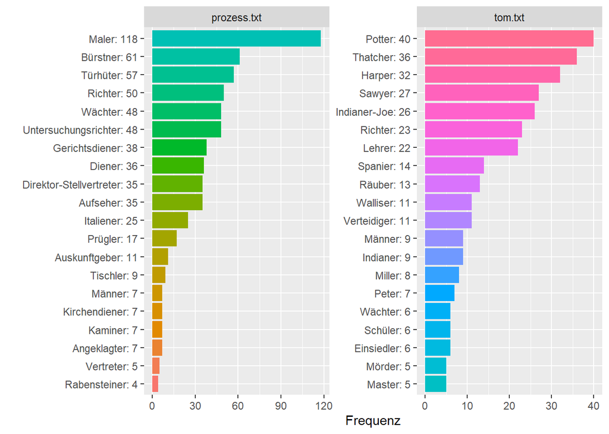

```r
nomina_er %>%
  group_by(docname) %>%
  count(keyword, sort = T) %>%
  slice_head(n=20) %>%
  mutate(keyword = reorder_within(keyword, n, n, sep = ": ")) %>%
  ggplot(aes(n, keyword, fill = keyword)) +
  geom_col() +
  theme(legend.position = "none") +
  facet_wrap(~ docname, scales = "free") +
  labs(x = "Frequenz", y = "")
```

## Pripona -ung

```r
(nomen_ung = as_tibble(kwic(woerter, pattern = "\\b[A-Z].+ung\\b",
                      valuetype = "regex", case_insensitive = FALSE))
)
```

```
## # A tibble: 1,025 x 7
##    docname    from    to pre            keyword     post             pattern
##    <chr>     <int> <int> <chr>          <chr>       <chr>            <fct>
##  1 prozess.~    19    19 Der Prozess F~ Verhaftung  , Gespräch mit ~ "\\b[A-Z].~
##  2 prozess.~   137   137 , den er in d~ Wohnung     noch niemals ge~ "\\b[A-Z].~
##  3 prozess.~   231   231 , als müsse m~ Erscheinung hinnehmen , und~ "\\b[A-Z].~
##  4 prozess.~   374   374 K . im Tone e~ Meldung     : » Es ist unmö~ "\\b[A-Z].~
##  5 prozess.~   420   420 und wie Frau ~ Störung     mir gegenüber v~ "\\b[A-Z].~
##  6 prozess.~   589   589 so weniger , ~ Hauptverän~ in der Anwesenh~ "\\b[A-Z].~
##  7 prozess.~   712   712 K . , machte ~ Bewegung    , als reiße er ~ "\\b[A-Z].~
##  8 prozess.~   873   873 Glück haben w~ Bestimmung  Ihrer Wächter ,~ "\\b[A-Z].~
##  9 prozess.~  1091  1091 , sondern die~ Bestechung  , und weiter ve~ "\\b[A-Z].~
## 10 prozess.~  1265  1265 wagte , ihn i~ Wohnung     zu überfallen ?~ "\\b[A-Z].~
## # ... with 1,015 more rows
```

V romanu Prozess je število pojavnic samostalnikov na -ung skoraj enkrat večje kot v Tomu. Mnogi samostalniki s pripono -ung so abstraktni in težje razumljivi kot konkretni samostalniki.

```r
nomen_ung %>%
  group_by(docname) %>%
  count(keyword, sort = T) %>%
  summarise(Freq = sum(n))
```

```
## # A tibble: 2 x 2
##   docname      Freq
##   <chr>       <int>
## 1 prozess.txt   672
## 2 tom.txt       353
```

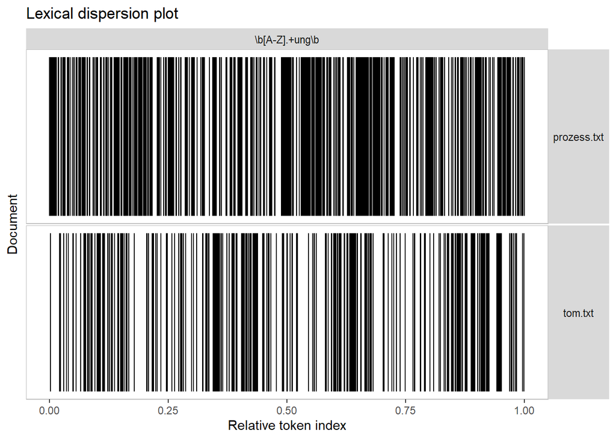

```r
kwic_ung = kwic(woerter, pattern = "\\b[A-Z].+ung\\b",
                      valuetype = "regex", case_insensitive = FALSE)
textplot_xray(kwic_ung)
```

Najpogostnejši samostalniki s pripono -ung odražajo osrednjo tematiko obeh besedil. V romanu Prozess se pogosteje pojavljajo samostalniki s pripono -ung, ki spadajo v pomensko polje “(kriminalno) pravo”, v romanu Tom Sawyer pa je na vrhu lestvice več takih samostalnikov, ki se nanašajo na geografski prostor in razpoloženje.

```r
library(tidytext)
(nomina_ung = nomen_ung %>%
  group_by(docname) %>%
  count(keyword, sort = T) %>%
  slice_head(n=20) %>%
  mutate(keyword = reorder_within(keyword, n, n, sep = ": "))
)
```

```
## # A tibble: 40 x 3
## # Groups:   docname [2]
##    docname     keyword               n
##    <chr>       <fct>             <int>
##  1 prozess.txt Verteidigung: 26     26
##  2 prozess.txt Meinung: 21          21
##  3 prozess.txt Bemerkung: 19        19
##  4 prozess.txt Erklärung: 19        19
##  5 prozess.txt Verhaftung: 18       18
##  6 prozess.txt Stellung: 17         17
##  7 prozess.txt Wohnung: 17          17
##  8 prozess.txt Freisprechung: 15    15
##  9 prozess.txt Bedeutung: 14        14
## 10 prozess.txt Verbindung: 14       14
## # ... with 30 more rows
```

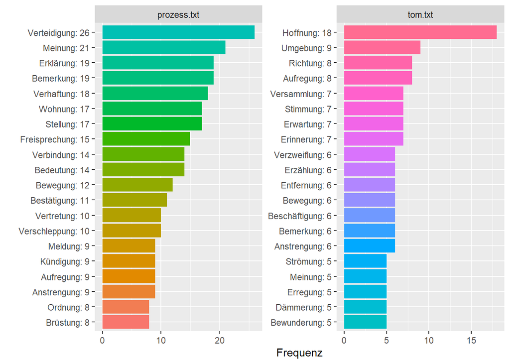

```r
nomina_ung %>%
  ggplot(aes(n, keyword, fill = keyword)) +
  geom_col() +
  theme(legend.position = "none") +
  facet_wrap(~ docname, scales = "free") +
  labs(x = "Frequenz", y = "")
```

Iskanje besednih zvez s funkcijo *kwic()* in *phrase()* - funkcijske glagolske zveze (Funktionsverbgefüge) in frazemi:

```r
(fvg1 =  as_tibble(kwic(woerter, pattern = phrase(
  c("zur|in .+ung (ge)komm.+|(ge)brach.+|bring.+")),
                 valuetype = "regex", case_insensitive = FALSE))
)
```

```
## # A tibble: 9 x 7
##   docname    from    to pre          keyword        post       pattern
##   <chr>     <int> <int> <chr>        <chr>          <chr>      <fct>
## 1 prozess.~  7059  7061 ; wenn ich ~ in Ordnung br~ will , bl~ zur|in .+ung (ge~
## 2 prozess.~  8040  8042 es ist auch~ in Ordnung ge~ , sehen S~ zur|in .+ung (ge~
## 3 prozess.~  9424  9426 meine Schul~ in Unordnung ~ worden , ~ zur|in .+ung (ge~
## 4 prozess.~ 10979 10981 , » ich wer~ in Ordnung br~ . Wer kan~ zur|in .+ung (ge~
## 5 prozess.~ 14537 14539 führte , ha~ seine Meldung~ . Zweimal~ zur|in .+ung (ge~
## 6 prozess.~ 25105 25107 zurückgehen~ meine Meldung~ und habe ~ zur|in .+ung (ge~
## 7 prozess.~ 57526 57528 zum erstenm~ in Verbindung~ ? « fragt~ zur|in .+ung (ge~
## 8 tom.txt   72134 72136 , mit den l~ in Verbindung~ zu werden~ zur|in .+ung (ge~
## 9 tom.txt   77725 77727 Abenteuer ,~ kleine Aussch~ ; er schl~ zur|in .+ung (ge~
```

Če so med sestavnimi deli besedne zveze drugi izrazi, lahko tudi postopoma filtriramo:

```r
phrase1 = "\\bstand.*|\\bsteh.*"

(fvg2 = as_tibble(kwic(woerter, pattern = phrase(phrase1), window = 10,
                 valuetype = "regex", case_insensitive = FALSE)) %>%
  filter(str_detect(post, "zur")) %>%
  filter(str_detect(post, ".+ung\\b"))
)
```

```
## # A tibble: 1 x 7
##   docname    from    to pre               keyword post               pattern
##   <chr>     <int> <int> <chr>             <chr>   <chr>              <fct>
## 1 prozess.~  6329  6329 aus dem Wagen , ~ stand   mit seinem Grinse~ "\\bstand.~
```

# 5. tidytext

Pretvorba besedil v povedi s programom tidytext, funkcija *unnest_tokens()*:

```r
romantexte = txt %>%
  as_tibble() %>%
  unnest_tokens(sentence, text, token = "sentences")
```

Izvleci samostalniške zveze:

```r
np = "(der|die|das|des|dem|den) ([^ ]+)"

romantexte %>%
  str_extract_all(np)
```

```
## [[1]]
## character(0)
##
## [[2]]
##     [1] "der prozess"                    "der prozess"
##     [3] "die köchin"                     "der frau"
##     [5] "die ihm"                        "den tag"
##     [7] "das frühstück"                  "das war"
##     [9] "die alte"                       "die ihm"
##    [11] "die ihn"                        "den er"
##    [13] "des schwarzes"                  "das ,"
##    [15] "den reiseanzügen"               "der mann"
##    [17] "die frage"                      "das frühstück"
##    [19] "der mann"                       "die er"
##    [21] "dem ,"                          "der offenbar"
```

[output cut: 6395 more lines]

```r
# romantexte %>%
#   str_match_all(np)
```

Izvleci FVG:

```r
nomphrase = "stand.*\\W(\\w+){1,3}\\szur\\s.+ung"
nomphrase = "stand.* (zur .+ung)"

romantexte %>%
  select(sentence) %>%
  str_extract_all(nomphrase) %>%
  head(10)
```

```
## [[1]]
## [1] "stand mit seinem grinsen zur verfügung"
## [2] "stande war , und es war für einen angeklagten beruhigend , sich vorzustellen , wie wenig geldmittel diesem gericht zur verfügung"
## [3] "stand langsam auf , sah fräulein montag an , dann über den tisch hin , dann aus dem fenster  –   das gegenüberliegende haus stand in der sonne  –   und ging zur tür .\", \"fräulein montag folgte ihm ein paar schritte , als vertraue sie ihm nicht ganz .\", \"vor der tür mußten aber beide zurü…
## [4] "stand des direktors zur stärkung"
```